# Simulating Data

Statistical Rethinking, Chapter 3

February, 2017

## From Likelihood to data

- the likelihood function tells probablity of particular data, given paramter values (according to the model)
- d-functions in R give the probabilities
- r-functions in R do random sampling using these probabilities

### Example: Sample of size 2

**Setting:** data set of size 2 assuming a proportion of 0.7 and a binomial model.

```r
dbinom(0:2, size = 2, prob = 0.7)
```

```
## [1] 0.09 0.42 0.49
```

```r
x <- rbinom(1e5, size = 2, prob = 0.7)
tally(x, format = "proportion")
```

```
## X
##       0       1       2
## 0.09062 0.41887 0.49051
```

### Example: Sample of size 9

**Setting:** data set of size 9 assuming a proportion of 0.7 and a binomial model.

```r
dbinom(0:9, size = 9, prob = 0.7)
```

```
##  [1] 1.968e-05 4.133e-04 3.858e-03 2.100e-02 7.351e-02 1.715e-01 2.668e-01
##  [8] 2.668e-01 1.556e-01 4.035e-02
```

```r
x <- rbinom(1e5, size = 9, prob = 0.7)
tally(x, format = "proportion")
```

```
## X
##       0       1       2       3       4       5       6       7       8
## 0.00002 0.00041 0.00377 0.02101 0.07273 0.17235 0.26736 0.26575 0.15656
##       9
## 0.04004
```

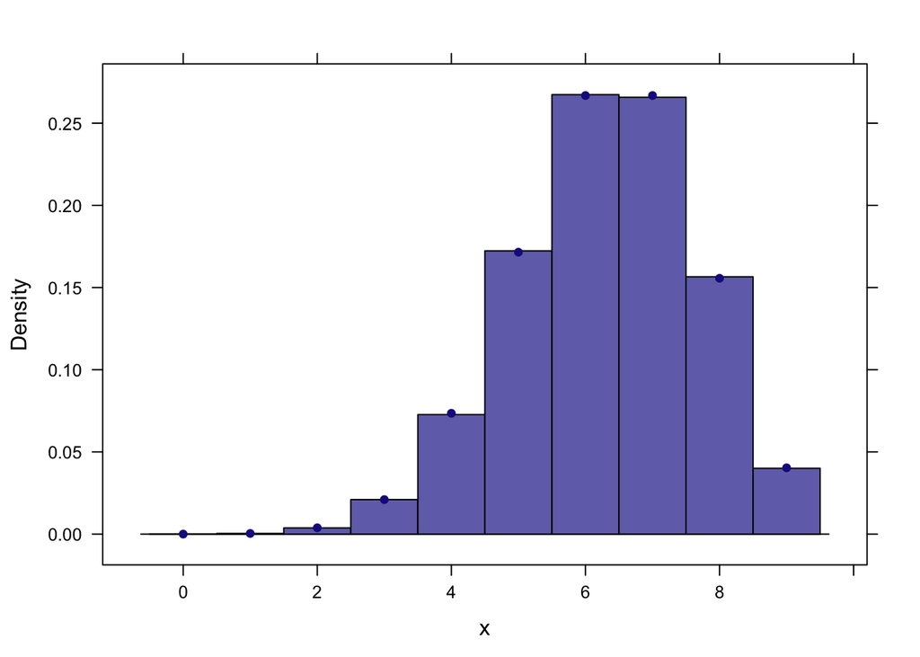

```r
histogram( ~ x, width = 1, format = "prop")
plotPoints(dbinom(0:9, size = 9, prob = 0.7) ~ 0:9, add = TRUE)
```

## Posterior + Likelihood -> Data

The likelihood functions tells us how to simulate data if (a) we know the paramter values and (b) the model is correct. (The model won’t every be “correct”, but comparing what the model things to other information can help us decide whether the model is “correct enough” for our purposes.)

But we don’t know the parameters, so we need to combine information from our posterior distribution with the likelihood function. Doing this combines two sources of uncertainty:

1. Observation Uncertainty: Even if we knew $p$ exactly, there would be variability from sample to sample.
2. Uncertainty about $p$: We don’t know $p$. The posterior distribution represents our uncertainty about $p$.

Because the d- and r-functions in R are vectorized, this is easily done.

Let’s begin by redoing our grid sampling (with better names this time)

```r
Water9Grid <-
  expand.grid(p = seq(0, 1, by = 0.001)) %>%       # create grid of values for p
  mutate(                                             # add additional variables
    prior = 1,                              # uniform prior, value gets recycled
    likelihood = dbinom(6, size = 9, prob = p),            # binomial probabilty
    posterior_raw = prior * likelihood,                    # kernel of posterior
    posterior1 = posterior_raw / sum(posterior_raw),        # easy normalization
    posterior = posterior_raw / sum(posterior_raw) / 0.001 # fancy normalization
  )
head(Water9Grid)
```

```
##       p prior likelihood posterior_raw posterior1 posterior
## 1 0.000     1  0.000e+00     0.000e+00  0.000e+00 0.000e+00
## 2 0.001     1  8.375e-17     8.375e-17  8.375e-19 8.375e-16
## 3 0.002     1  5.344e-15     5.344e-15  5.344e-17 5.344e-14
## 4 0.003     1  6.069e-14     6.069e-14  6.069e-16 6.069e-13
## 5 0.004     1  3.400e-13     3.400e-13  3.400e-15 3.400e-12
## 6 0.005     1  1.293e-12     1.293e-12  1.293e-14 1.293e-11
```

[figure not shown]

[figure not shown]

Now we can simulate water counts taking into account both types of uncertainty

```r
w <- rbinom(1e4, size = 9, prob = Water9Post$p)
```

and compare the results with our observed data. In this case, things are looking very reasonable – the data we observed seem to match what the model expects quite well.

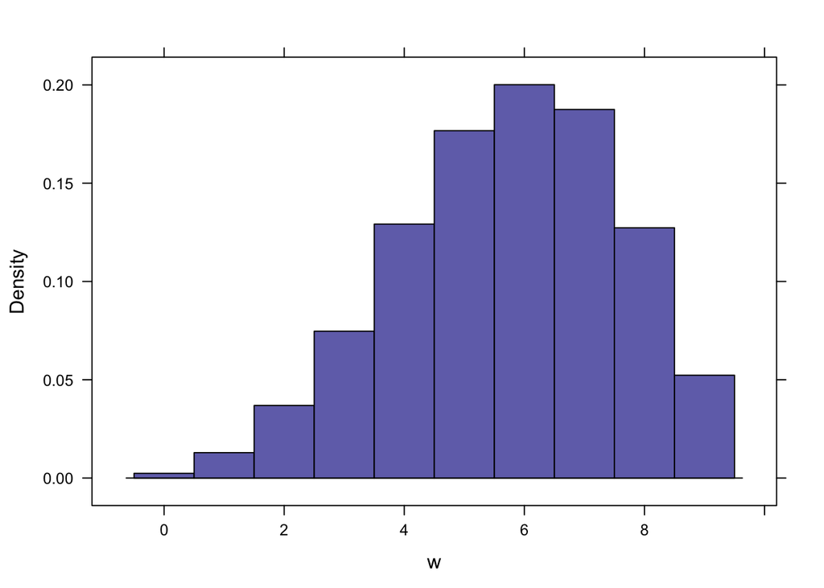

```r
histogram( ~ w, width = 1)
```

### A fancier check

Now lets determine how often a random data set switches between water and land. (In the book example, there were 6 switches in 9 observations: W L WWW L W L W.

Do do this, we need to simulate individual observations, not just the count of water. Here is one way to do that.

```r
Dummy_data <-
  do(1e4) * rbinom(9, size = 1, prob = sample(Water9Post$p, 1))
```

[output not shown]

```r
head(Dummy_data)
```

```
##   V1 V2 V3 V4 V5 V6 V7 V8 V9
## 1  1  0  1  0  1  0  1  0  1
## 2  0  0  1  1  0  1  1  1  1
## 3  1  1  0  0  1  0  0  1  1
## 4  0  1  1  1  1  1  1  0  1
## 5  0  0  0  1  0  0  1  1  1
## 6  0  0  0  0  1  1  1  1  0
```

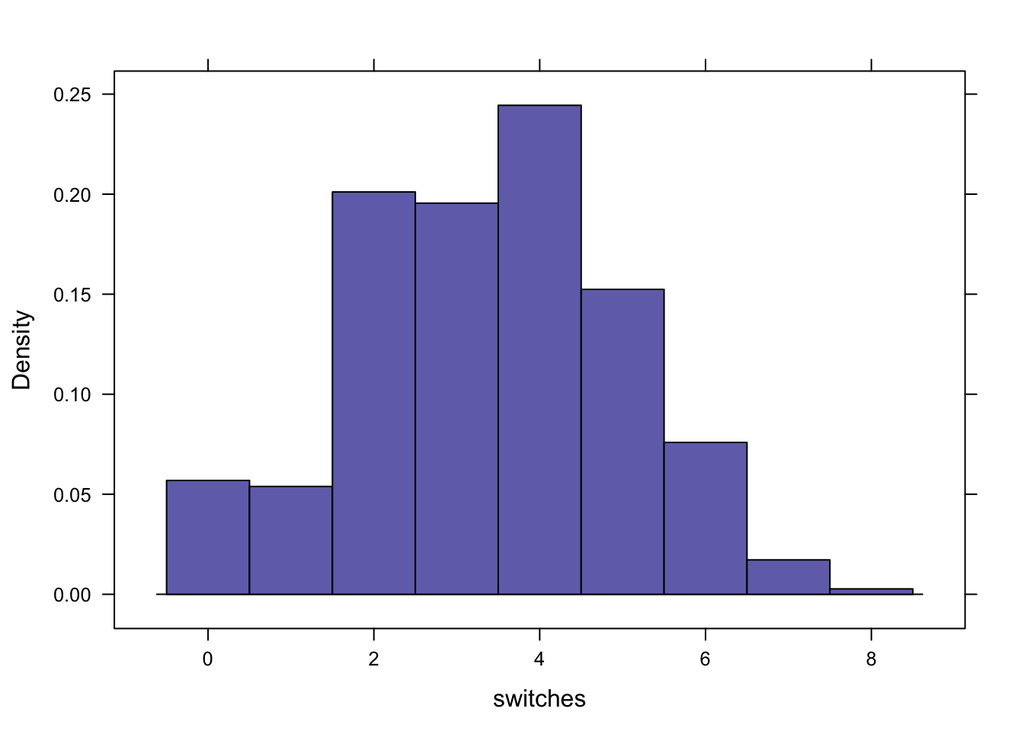

```r
switches <- apply(as.matrix(Dummy_data), 1, function(x) sum(abs(diff(x))))
histogram( ~ switches, width = 1)
```

By comparision, our data had quite a few swithces – not impossibly many, but more than we might have expected.

## Big Idea

The posterior distribution is computed assuming that the prior and likelihood are correct, so the posterior expresses the “model’s view of the world”. But we should get in the habbit of doing some checking to see that the model’s view of the world agrees with our own reasonably well. If it does not, we may need to adjust our model.